# Big Data Analytics: SPARCS 2016 Hospital Inpatient Discharge Analysis

# Pearson Correlation Matrix

## Base R Correlation

```r
numeric_df <- spark_numeric %>%
  collect()


cor_matrix <- cor(
  numeric_df,
  use = "pairwise.complete.obs",
  method = "pearson"
)


round(
  cor_matrix,
  2
)
```

```
##                              Length_of_Stay CCS_Diagnosis_Code
## Length_of_Stay                         1.00               0.11
## CCS_Diagnosis_Code                     0.11               1.00
## CCS_Procedure_Code                     0.06               0.13
## APR_DRG_Code                           0.07               0.44
## APR_MDC_Code                           0.09               0.46
## APR_Severity_of_Illness_Code           0.35              -0.20
## Birth_Weight                          -0.10               0.05
## Total_Charges                          0.69              -0.11
## Total_Costs                            0.70              -0.10
##                              CCS_Procedure_Code APR_DRG_Code APR_MDC_Code
## Length_of_Stay                             0.06         0.07         0.09
## CCS_Diagnosis_Code                         0.13         0.44         0.46
## CCS_Procedure_Code                         1.00         0.20         0.20
## APR_DRG_Code                               0.20         1.00         0.95
## APR_MDC_Code                               0.20         0.95         1.00
## APR_Severity_of_Illness_Code              -0.03        -0.11        -0.11
## Birth_Weight                               0.14         0.29         0.26
## Total_Charges                              0.03        -0.10        -0.08
## Total_Costs                                0.04        -0.10        -0.07
##                              APR_Severity_of_Illness_Code Birth_Weight
## Length_of_Stay                                       0.35        -0.10
## CCS_Diagnosis_Code                                  -0.20         0.05
## CCS_Procedure_Code                                  -0.03         0.14
## APR_DRG_Code                                        -0.11         0.29
## APR_MDC_Code                                        -0.11         0.26
## APR_Severity_of_Illness_Code                         1.00        -0.26
## Birth_Weight                                        -0.26         1.00
## Total_Charges                                        0.34        -0.13
## Total_Costs                                          0.33        -0.13
##                              Total_Charges Total_Costs
## Length_of_Stay                        0.69        0.70
## CCS_Diagnosis_Code                   -0.11       -0.10
## CCS_Procedure_Code                    0.03        0.04
## APR_DRG_Code                         -0.10       -0.10
## APR_MDC_Code                         -0.08       -0.07
## APR_Severity_of_Illness_Code          0.34        0.33
## Birth_Weight                         -0.13       -0.13
## Total_Charges                         1.00        0.92
## Total_Costs                           0.92        1.00
```

## Spark Correlation

```r
spark_cor_matrix <- ml_corr(
  spark_numeric,
  method = "pearson"
)


round(
  spark_cor_matrix,
  2
)
```

```
## # A tibble: 9 × 9
##   Length_of_Stay CCS_Diagnosis_Code CCS_Procedure_Code APR_DRG_Code APR_MDC_Code
##            <dbl>              <dbl>              <dbl>        <dbl>        <dbl>
## 1           1                  0.11               0.06         0.07         0.09
## 2           0.11               1                  0.13         0.44         0.46
## 3           0.06               0.13               1            0.2          0.2
## 4           0.07               0.44               0.2          1            0.95
## 5           0.09               0.46               0.2          0.95         1
## 6           0.35              -0.2               -0.03        -0.11        -0.11
## 7          -0.1                0.05               0.14         0.29         0.26
## 8           0.69              -0.11               0.03        -0.1         -0.08
## 9           0.7               -0.1                0.04        -0.1         -0.07
## # ℹ 4 more variables: APR_Severity_of_Illness_Code <dbl>, Birth_Weight <dbl>,
## #   Total_Charges <dbl>, Total_Costs <dbl>
```

## Correlation Using corrr

```r
corrr_matrix <- numeric_df %>%
  correlate(
    use = "pairwise.complete.obs",
    method = "pearson"
  )


corrr_matrix
```

```
## # A tibble: 9 × 10
##   term         Length_of_Stay CCS_Diagnosis_Code CCS_Procedure_Code APR_DRG_Code
##   <chr>                 <dbl>              <dbl>              <dbl>        <dbl>
## 1 Length_of_S…        NA                  0.106              0.0635       0.0720
## 2 CCS_Diagnos…         0.106             NA                  0.133        0.437
## 3 CCS_Procedu…         0.0635             0.133             NA            0.202
## 4 APR_DRG_Code         0.0720             0.437              0.202       NA
## 5 APR_MDC_Code         0.0891             0.464              0.200        0.953
## 6 APR_Severit…         0.350             -0.196             -0.0257      -0.108
## 7 Birth_Weight        -0.0976             0.0548             0.145        0.295
## 8 Total_Charg…         0.690             -0.105              0.0295      -0.103
## 9 Total_Costs          0.704             -0.0962             0.0359      -0.0988
## # ℹ 5 more variables: APR_MDC_Code <dbl>, APR_Severity_of_Illness_Code <dbl>,
## #   Birth_Weight <dbl>, Total_Charges <dbl>, Total_Costs <dbl>
```

# Correlation Heatmap

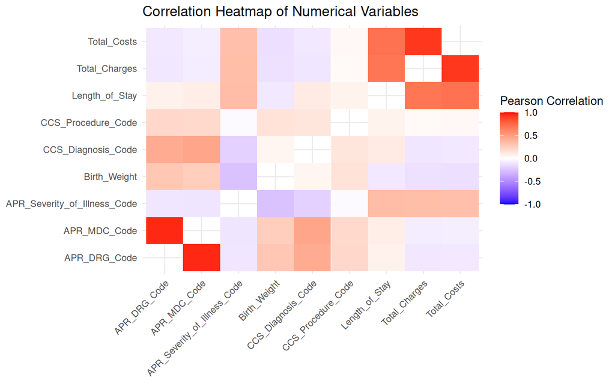

```r
heatmap_data <- corrr_matrix %>%
  stretch()


heatmap_data %>%
  filter(
    !is.na(r)
  ) %>%
  ggplot(
    aes(
      x = x,
      y = y,
      fill = r
    )
  ) +
  geom_tile() +
  scale_fill_gradient2(
    low = "blue",
    mid = "white",
    high = "red",
    midpoint = 0,
    limits = c(-1,1)
  ) +
  theme_minimal() +
  theme(
    axis.text.x = element_text(
      angle = 45,
      hjust = 1
    )
  ) +
  labs(
    title = "Correlation Heatmap of Numerical Variables",
    x = NULL,
    y = NULL,
    fill = "Pearson Correlation"
  )
```

# Train-Test Split

The dataset was divided into training and testing datasets for subsequent machine learning models.

```r
set.seed(6082026)


spark_split <- sdf_random_split(
  sparcs_clean,
  training = 0.8,
  test = 0.2,
  seed = 6082026
)


train_spark <- spark_split$training

test_spark <- spark_split$test


sdf_dim(train_spark)
```

```
## [1] 1873334      34
```

```r
sdf_dim(test_spark)
```

```
## [1] 468342     34
```

## rsample::initial_split()

```r
library(rsample)

# rsample requires an in-memory (local) data frame, unlike sdf_random_split()
# which operates directly on the distributed Spark data frame.
# numeric_df (collected earlier for correlation analysis) is reused here.

set.seed(6082026)

rsample_split <- initial_split(
  numeric_df,
  prop = 0.8
)

train_rsample <- training(rsample_split)

test_rsample <- testing(rsample_split)

nrow(train_rsample)
```

```
## [1] 1873340
```

```r
nrow(test_rsample)
```

```
## [1] 468336
```

**Note:** `sdf_random_split()` partitions data **inside Spark’s distributed engine** (scales to the full 2.3M rows without collecting to R), while `rsample::initial_split()` partitions an **in-memory R data frame** — appropriate for smaller, already-collected datasets.

# 3. Exploratory Data Analysis (EDA)

## Overview

Exploratory Data Analysis was performed to understand patient characteristics, admission patterns, financial variables, and clinical severity distributions within the SPARCS dataset.

# Dataset Dimensions

```r
sdf_dim(sparcs_clean)
```

```
## [1] 2341676      34
```

# Summary Statistics

```r
sparcs_clean %>%
  summarise(
    Mean_LOS = mean(
      Length_of_Stay,
      na.rm = TRUE
    ),

    Mean_Charges = mean(
      Total_Charges,
      na.rm = TRUE
    ),

    Mean_Costs = mean(
      Total_Costs,
      na.rm = TRUE
    ),

    Mean_Severity = mean(
      APR_Severity_of_Illness_Code,
      na.rm = TRUE
    )
  ) %>%
  collect()
```

```
## # A tibble: 1 × 4
##   Mean_LOS Mean_Charges Mean_Costs Mean_Severity
##      <dbl>        <dbl>      <dbl>         <dbl>
## 1     5.32       45156.     15376.          2.02
```

# Length of Stay Statistics

```r
sparcs_clean %>%
  summarise(

    Mean_LOS = mean(
      Length_of_Stay,
      na.rm = TRUE
    ),

    Min_LOS = min(
      Length_of_Stay,
      na.rm = TRUE
    ),

    Max_LOS = max(
      Length_of_Stay,
      na.rm = TRUE
    )

  ) %>%
  collect()
```

```
## # A tibble: 1 × 3
##   Mean_LOS Min_LOS Max_LOS
##      <dbl>   <dbl>   <dbl>
## 1     5.32       1     119
```

# Total Charges Statistics

```r
sparcs_clean %>%
  summarise(

    Mean_Charges = mean(
      Total_Charges,
      na.rm = TRUE
    ),

    Min_Charges = min(
      Total_Charges,
      na.rm = TRUE
    ),

    Max_Charges = max(
      Total_Charges,
      na.rm = TRUE
    )

  ) %>%
  collect()
```

```
## # A tibble: 1 × 3
##   Mean_Charges Min_Charges Max_Charges
##          <dbl>       <dbl>       <dbl>
## 1       45156.        0.01    4795126.
```

# Total Costs Statistics

```r
sparcs_clean %>%
  summarise(

    Mean_Costs = mean(
      Total_Costs,
      na.rm = TRUE
    ),

    Min_Costs = min(
      Total_Costs,
      na.rm = TRUE
    ),

    Max_Costs = max(
      Total_Costs,
      na.rm = TRUE
    )

  ) %>%
  collect()
```

```
## # A tibble: 1 × 3
##   Mean_Costs Min_Costs Max_Costs
##        <dbl>     <dbl>     <dbl>
## 1     15376.         0  1727205.
```

# Numerical Quantiles

The 75th percentile values were calculated to understand the upper range of hospital stay and financial variables.

```r
sparcs_clean %>%
  summarise(

    LOS_75th = percentile_approx(
      Length_of_Stay,
      0.75
    ),

    Cost_75th = percentile_approx(
      Total_Costs,
      0.75
    ),

    Charges_75th = percentile_approx(
      Total_Charges,
      0.75
    )

  ) %>%
  collect()
```

```
## # A tibble: 1 × 3
##   LOS_75th Cost_75th Charges_75th
##      <dbl>     <dbl>        <dbl>
## 1        6    16680.       49285.
```

# Age Group Distribution

```r
sparcs_clean %>%
  group_by(
    Age_Group
  ) %>%
  summarise(
    Count = n()
  ) %>%
  arrange(
    desc(Count)
  ) %>%
  collect()
```

```
## # A tibble: 5 × 2
##   Age_Group    Count
##   <chr>        <dbl>
## 1 50 to 69    653955
## 2 70 or Older 642333
## 3 30 to 49    454624
## 4 0 to 17     347275
## 5 18 to 29    243489
```

# Gender Distribution

```r
sparcs_clean %>%
  group_by(
    Gender
  ) %>%
  summarise(
    Count = n()
  ) %>%
  arrange(
    desc(Count)
  ) %>%
  collect()
```

```
## # A tibble: 3 × 2
##   Gender   Count
##   <chr>    <dbl>
## 1 F      1300934
## 2 M      1040685
## 3 U           57
```

# Race Distribution

```r
sparcs_clean %>%
  group_by(
    Race
  ) %>%
  summarise(
    Count = n()
  ) %>%
  arrange(
    desc(Count)
  ) %>%
  collect()
```

```
## # A tibble: 4 × 2
##   Race                     Count
##   <chr>                    <dbl>
## 1 White                  1319582
## 2 Other Race              562803
## 3 Black/African American  430031
## 4 Multi-racial             29260
```

# Ethnicity Distribution

```r
sparcs_clean %>%
  group_by(
    Ethnicity
  ) %>%
  summarise(
    Count = n()
  ) %>%
  arrange(
    desc(Count)
  ) %>%
  collect()
```

```
## # A tibble: 4 × 2
##   Ethnicity           Count
##   <chr>               <dbl>
## 1 Not Span/Hispanic 1933315
## 2 Spanish/Hispanic   300894
## 3 Unknown             97098
## 4 Multi-ethnic        10369
```

# Type of Admission Distribution

```r
sparcs_clean %>%
  group_by(
    Type_of_Admission
  ) %>%
  summarise(
    Count = n()
  ) %>%
  arrange(
    desc(Count)
  ) %>%
  collect()
```

```
## # A tibble: 6 × 2
##   Type_of_Admission   Count
##   <chr>               <dbl>
## 1 Emergency         1497899
## 2 Elective           440940
## 3 Newborn            224562
## 4 Urgent             171219
## 5 Trauma               6621
## 6 Not Available         435
```

# Patient Disposition Distribution

```r
sparcs_clean %>%
  group_by(
    Patient_Disposition
  ) %>%
  summarise(
    Count = n()
  ) %>%
  arrange(
    desc(Count)
  ) %>%
  collect()
```

```
## # A tibble: 19 × 2
##    Patient_Disposition                     Count
##    <chr>                                   <dbl>
##  1 Home or Self Care                     1561730
##  2 Home w/ Home Health Services           316339
##  3 Skilled Nursing Home                   220369
##  4 Expired                                 49822
##  5 Left Against Medical Advice             48265
##  6 Inpatient Rehabilitation Facility       44083
##  7 Short-term Hospital                     39857
##  8 Hospice - Medical Facility              12823
##  9 Hospice - Home                          11634
## 10 Psychiatric Hospital or Unit of Hosp    11611
## 11 Another Type Not Listed                  6925
## 12 Facility w/ Custodial/Supportive Care    6408
## 13 Court/Law Enforcement                    4268
## 14 Medicare Cert Long Term Care Hospital    2277
## 15 Cancer Center or Children's Hospital     2026
## 16 Hosp Basd Medicare Approved Swing Bed    1513
## 17 Medicaid Cert Nursing Facility            902
## 18 Federal Health Care Facility              693
## 19 Critical Access Hospital                  131
```

# Severity of Illness Distribution

```r
sparcs_clean %>%
  group_by(
    APR_Severity_of_Illness_Description
  ) %>%
  summarise(
    Count = n()
  ) %>%
  arrange(
    desc(Count)
  ) %>%
  collect()
```

```
## # A tibble: 5 × 2
##   APR_Severity_of_Illness_Description  Count
##   <chr>                                <dbl>
## 1 Moderate                            888544
## 2 Minor                               774498
## 3 Major                               527522
## 4 Extreme                             151045
## 5 <NA>                                    67
```

# Home Discharge Distribution

A binary outcome variable was created for classification modelling.

Patients discharged to **Home or Self Care** were classified as “Yes”, while all other discharge destinations were classified as “No”.

```r
sparcs_clean %>%
  mutate(
    Discharged_Home = ifelse(
      Patient_Disposition == "Home or Self Care",
      "Yes",
      "No"
    )
  ) %>%
  group_by(
    Discharged_Home
  ) %>%
  summarise(
    Count = n()
  ) %>%
  collect()
```

```
## # A tibble: 2 × 2
##   Discharged_Home   Count
##   <chr>             <dbl>
## 1 No               779946
## 2 Yes             1561730
```

# 4. Predictive Modelling

Two predictive modelling approaches were developed:

1. Regression models to predict **Total Hospital Costs**
2. Classification models to predict **Home Discharge**

## Automated Regression Function

A reusable function that automates fitting, prediction, and evaluation for any Spark linear regression model:

```r
run_spark_regression <- function(
  train_data,
  test_data,
  formula,
  label_col
) {

  model <- ml_linear_regression(
    train_data,
    formula
  )

  predictions <- ml_predict(
    model,
    test_data
  )

  # Extract label column name from formula
  label <- as.character(formula)[2]

  # Collect predictions and compute metrics manually
  pred_collected <- predictions %>%
    select(
      all_of(label),
      prediction
    ) %>%
    collect()

  rmse <- pred_collected %>%
    summarise(
      rmse = sqrt(
        mean((!!sym(label) - prediction)^2, na.rm = TRUE)
      )
    ) %>%
    pull(rmse)

  # Compute R2: 1 - (SS_res / SS_tot)
  ss_res <- pred_collected %>%
    summarise(
      ss_res = sum((!!sym(label) - prediction)^2, na.rm = TRUE)
    ) %>%
    pull(ss_res)

  ss_tot <- pred_collected %>%
    summarise(
      ss_tot = sum(
        (!!sym(label) - mean(!!sym(label), na.rm = TRUE))^2,
        na.rm = TRUE
      )
    ) %>%
    pull(ss_tot)

  r2 <- 1 - (ss_res / ss_tot)

  list(
    model = model,
    coefficients = tidy(model),
    predictions = predictions,
    rmse = rmse,
    r2 = r2
  )

}
```

## Apply Automated Function — Simple Linear Regression

```r
slr_results <- run_spark_regression(
  train_spark,
  test_spark,
  Total_Costs ~ Length_of_Stay,
  "Total_Costs"
)

slr_results$rmse
```

```
## [1] 18852.38
```

```r
slr_results$r2
```

```
## [1] 0.4877601
```

## Apply Automated Function — Multiple Linear Regression

```r
multiple_results <- run_spark_regression(
  train_spark,
  test_spark,
  Total_Costs ~ Length_of_Stay + APR_Severity_of_Illness_Code,
  "Total_Costs"
)

multiple_results$rmse
```

```
## [1] 18692.42
```

```r
multiple_results$r2
```

```
## [1] 0.4964158
```

# Regression Analysis

## Simple Linear Regression

Predicting total hospital costs using length of stay.

```r
slr_model <- ml_linear_regression(
  train_spark,
  Total_Costs ~ Length_of_Stay
)


slr_model
```

```
## Formula: Total_Costs ~ Length_of_Stay
##
## Coefficients:
##    (Intercept) Length_of_Stay
##       2219.652       2471.747
```

```r
slr_coefficients <- tidy(
  slr_model
)


slr_coefficients
```

```
## # A tibble: 2 × 5
##   term           estimate std.error statistic p.value
##   <chr>             <dbl>     <dbl>     <dbl>   <dbl>
## 1 (Intercept)       2220.     16.4       135.       0
## 2 Length_of_Stay    2472.      1.82     1362.       0
```

## Standardization

Standardize predictors using training-set statistics only, to avoid data leakage:

```r
train_stats <- train_spark %>%
  summarise(
    mean_LOS = mean(
      Length_of_Stay,
      na.rm = TRUE
    ),
    sd_LOS = sd(
      Length_of_Stay,
      na.rm = TRUE
    ),
    mean_Severity = mean(
      APR_Severity_of_Illness_Code,
      na.rm = TRUE
    ),
    sd_Severity = sd(
      APR_Severity_of_Illness_Code,
      na.rm = TRUE
    )
  ) %>%
  collect()

train_spark_scaled <- train_spark %>%
  mutate(
    Length_of_Stay_scaled = (
      Length_of_Stay - !!train_stats$mean_LOS
    ) / !!train_stats$sd_LOS,
    Severity_scaled = (
      APR_Severity_of_Illness_Code - !!train_stats$mean_Severity
    ) / !!train_stats$sd_Severity
  )

test_spark_scaled <- test_spark %>%
  mutate(
    Length_of_Stay_scaled = (
      Length_of_Stay - !!train_stats$mean_LOS
    ) / !!train_stats$sd_LOS,
    Severity_scaled = (
      APR_Severity_of_Illness_Code - !!train_stats$mean_Severity
    ) / !!train_stats$sd_Severity
  )

multiple_model_scaled <- ml_linear_regression(
  train_spark_scaled,
  Total_Costs ~ Length_of_Stay_scaled + Severity_scaled
)

tidy(multiple_model_scaled)
```

```
## # A tibble: 3 × 5
##   term                  estimate std.error statistic p.value
##   <chr>                    <dbl>     <dbl>     <dbl>   <dbl>
## 1 (Intercept)             15367.      13.2     1168.       0
## 2 Length_of_Stay_scaled   17170.      14.0     1222.       0
## 3 Severity_scaled          2595.      14.0      185.       0
```

## Multiple Linear Regression

Predicting total hospital costs using:

- Length of Stay
- Severity of Illness

```r
multiple_model <- ml_linear_regression(
  train_spark,
  Total_Costs ~ Length_of_Stay +
    APR_Severity_of_Illness_Code
)


multiple_coefficients <- tidy(
  multiple_model
)


multiple_coefficients
```

```
## # A tibble: 3 × 5
##   term                         estimate std.error statistic p.value
##   <chr>                           <dbl>     <dbl>     <dbl>   <dbl>
## 1 (Intercept)                    -2941.     32.3      -91.0       0
## 2 Length_of_Stay                  2348.      1.92    1222.        0
## 3 APR_Severity_of_Illness_Code    2877.     15.6      185.        0
```

## Parsnip Comparison

```r
library(parsnip)
library(yardstick)

# parsnip/tidymodels fits locally, so a sample is collected from Spark
regression_sample <- train_spark %>%
  select(
    Total_Costs,
    Length_of_Stay,
    APR_Severity_of_Illness_Code
  ) %>%
  sdf_sample(
    fraction = 0.05,
    seed = 6082026
  ) %>%
  collect()

test_sample_local <- test_spark %>%
  select(
    Total_Costs,
    Length_of_Stay,
    APR_Severity_of_Illness_Code
  ) %>%
  sdf_sample(
    fraction = 0.05,
    seed = 6082026
  ) %>%
  collect()

lm_parsnip_fit <- linear_reg() %>%
  set_engine("lm") %>%
  fit(
    Total_Costs ~ Length_of_Stay + APR_Severity_of_Illness_Code,
    data = regression_sample
  )

tidy(lm_parsnip_fit)
```

```
## # A tibble: 3 × 5
##   term                         estimate std.error statistic  p.value
##   <chr>                           <dbl>     <dbl>     <dbl>    <dbl>
## 1 (Intercept)                    -2864.    138.       -20.8 1.37e-95
## 2 Length_of_Stay                  2326.      8.28     281.  0
## 3 APR_Severity_of_Illness_Code    2907.     66.5       43.7 0
```

```r
parsnip_predictions <- predict(
  lm_parsnip_fit,
  new_data = test_sample_local
) %>%
  bind_cols(test_sample_local)

parsnip_rmse <- parsnip_predictions %>%
  rmse(
    truth = Total_Costs,
    estimate = .pred
  )

# Recreate Spark predictions fresh to avoid stale reference
spark_predictions_fresh <- ml_predict(
  multiple_model,
  test_spark
)

spark_rmse <- spark_predictions_fresh %>%
  select(
    Total_Costs,
    prediction
  ) %>%
  collect() %>%
  mutate(
    squared_error = (Total_Costs - prediction)^2
  ) %>%
  summarise(
    mse = mean(squared_error, na.rm = TRUE),
    rmse = sqrt(mse)
  ) %>%
  pull(rmse)

model_comparison <- tibble(
  Model = c(
    "Spark (ml_linear_regression)",
    "Parsnip (lm engine)"
  ),
  RMSE = c(
    spark_rmse,
    parsnip_rmse$.estimate
  )
)

model_comparison
```

```
## # A tibble: 2 × 2
##   Model                          RMSE
##   <chr>                         <dbl>
## 1 Spark (ml_linear_regression) 18692.
## 2 Parsnip (lm engine)          19194.
```

# Regression Predictions

```r
regression_predictions <- ml_predict(
  multiple_model,
  test_spark
)


regression_predictions %>%
  select(
    Total_Costs,
    prediction
  ) %>%
  head(10) %>%
  collect()
```

```
## # A tibble: 10 × 2
##    Total_Costs prediction
##          <dbl>      <dbl>
##  1       8525.     12204.
##  2       3369.      9326.
##  3       2600.      4631.
##  4       4745.     12204.
##  5       1737.      4631.
##  6       1037.      4631.
##  7       4507.      9856.
##  8       3677.      9856.
##  9        598.      4631.
## 10       6034.      9856.
```

# Regression Diagnostics

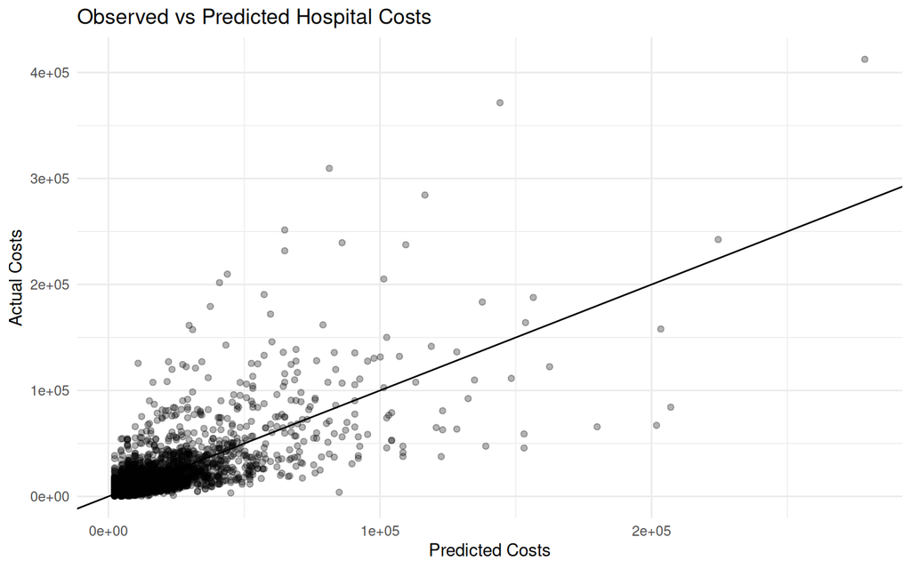

```r
regression_predictions %>%
  sdf_sample(
    fraction = 0.01
  ) %>%
  select(
    prediction,
    Total_Costs
  ) %>%
  collect() %>%
  ggplot(
    aes(
      x = prediction,
      y = Total_Costs
    )
  ) +
  geom_point(
    alpha = 0.3
  ) +
  geom_abline(
    intercept = 0,
    slope = 1
  ) +
  labs(
    title =
      "Observed vs Predicted Hospital Costs",
    x =
      "Predicted Costs",
    y =
      "Actual Costs"
  ) +
  theme_minimal()
```

# Classification Analysis

## Create Classification Dataset

Patients discharged to **Home or Self Care** were classified as “Yes”.

```r
classification_data <- sparcs_clean %>%
  mutate(
    Discharged_Home =
      ifelse(
        Patient_Disposition ==
          "Home or Self Care",
        "Yes",
        "No"
      )
  ) %>%
  select(
    Discharged_Home,
    Length_of_Stay,
    Total_Charges,
    Total_Costs,
    APR_Severity_of_Illness_Code,
    Age_Group,
    Gender,
    Race,
    Ethnicity,
    Type_of_Admission
  )
```

# Classification Sample

A sample was used because tree-based models require more memory.

```r
classification_sample <- classification_data %>%
  sdf_sample(
    fraction = 0.1
  )


class_split <- sdf_random_split(
  classification_sample,
  training = 0.8,
  test = 0.2,
  seed = 6082026
)


class_train_spark <- class_split$training

class_test_spark <- class_split$test


sdf_dim(class_train_spark)
```

```
## [1] 187075     10
```

```r
sdf_dim(class_test_spark)
```

```
## [1] 46489    10
```

# Logistic Regression

```r
logistic_model <- ml_logistic_regression(
  class_train_spark,
  Discharged_Home ~ .
)


logistic_model
```

```
## Formula: Discharged_Home ~ .
##
## Coefficients:
##                  (Intercept)               Length_of_Stay
##                -3.494109e+00                 2.328253e-02
##                Total_Charges                  Total_Costs
##                 1.620378e-06                 8.187884e-06
## APR_Severity_of_Illness_Code           Age_Group_50 to 69
##                 5.648921e-01                 1.161643e+00
##        Age_Group_70 or Older           Age_Group_30 to 49
##                 2.153174e+00                 3.647144e-01
##            Age_Group_0 to 17                     Gender_F
##                -3.089339e-01                 6.503472e-03
##                     Gender_M                   Race_White
##                -1.000568e-02                -5.217256e-03
##              Race_Other Race  Race_Black/African American
##                -1.706211e-01                 7.599428e-04
##  Ethnicity_Not Span/Hispanic   Ethnicity_Spanish/Hispanic
##                 1.107557e-01                 7.681303e-03
##            Ethnicity_Unknown  Type_of_Admission_Emergency
##                 1.009296e-01                 7.322781e-02
##   Type_of_Admission_Elective    Type_of_Admission_Newborn
##                 2.989531e-01                -4.160444e-01
##     Type_of_Admission_Urgent     Type_of_Admission_Trauma
##                -1.497482e-01                 6.022390e-01
```

# Random Forest

```r
rf_model <- ml_random_forest_classifier(
  class_train_spark,
  Discharged_Home ~ .,
  num_trees = 50,
  max_depth = 10
)


rf_model
```

```
## Formula: Discharged_Home ~ .
##
## RandomForestClassificationModel: uid=random_forest_classifier__4a367118_a988_4645_bfb3_7c034f2d4996, numTrees=50, numClasses=2, numFeatures=21
```

# Gradient Boosted Trees

```r
gbt_model <- ml_gbt_classifier(
  class_train_spark,
  Discharged_Home ~ .,
  max_iter = 20
)


gbt_model
```

```
## Formula: Discharged_Home ~ .
##
## GBTClassificationModel: uid = gbt_classifier__a803ea8b_5306_4ccd_a6d7_b7c1a8e86b3c, numTrees=20, numClasses=2, numFeatures=21
```

# Classification Predictions

# Model Predictions

```r
logistic_predictions <- ml_predict(
  logistic_model,
  class_test_spark
)

rf_predictions <- ml_predict(
  rf_model,
  class_test_spark
)

gbt_predictions <- ml_predict(
  gbt_model,
  class_test_spark
)
```

# Accuracy Comparison

```r
calculate_accuracy <- function(
  predictions,
  model_name
){

  results <- predictions %>%
    select(
      Discharged_Home,
      predicted_label
    ) %>%
    collect()


  results %>%
    summarise(
      Accuracy = mean(
        as.character(Discharged_Home) == as.character(predicted_label)
      ),
      Model = model_name
    )

}


full_accuracy_results <- bind_rows(

  calculate_accuracy(
    logistic_predictions,
    "Logistic Regression"
  ),

  calculate_accuracy(
    rf_predictions,
    "Random Forest"
  ),

  calculate_accuracy(
    gbt_predictions,
    "Gradient Boosted Trees"
  )

)


full_accuracy_results
```

```
## # A tibble: 3 × 2
##   Accuracy Model
##      <dbl> <chr>
## 1    0.764 Logistic Regression
## 2    0.784 Random Forest
## 3    0.783 Gradient Boosted Trees
```

# Feature Importance

```r
rf_importance <- ml_feature_importances(
  rf_model
)


rf_importance
```

```
##                         feature   importance
## 1         Age_Group_70 or Older 0.3049292736
## 2  APR_Severity_of_Illness_Code 0.1987423453
## 3                Length_of_Stay 0.1290405034
## 4                   Total_Costs 0.1123763337
## 5                 Total_Charges 0.0815026165
## 6            Age_Group_50 to 69 0.0457724509
## 7             Age_Group_0 to 17 0.0336764037
## 8            Age_Group_30 to 49 0.0272880812
## 9     Type_of_Admission_Newborn 0.0150971369
## 10  Type_of_Admission_Emergency 0.0149655306
## 11   Type_of_Admission_Elective 0.0073353596
## 12                     Gender_F 0.0070589498
## 13                     Gender_M 0.0064476651
## 14                   Race_White 0.0038274641
## 15              Race_Other Race 0.0029163869
## 16  Ethnicity_Not Span/Hispanic 0.0022110776
## 17   Ethnicity_Spanish/Hispanic 0.0021054458
## 18     Type_of_Admission_Urgent 0.0016794899
## 19  Race_Black/African American 0.0016540908
## 20            Ethnicity_Unknown 0.0008834715
## 21     Type_of_Admission_Trauma 0.0004899231
```

# Feature Importance Plot

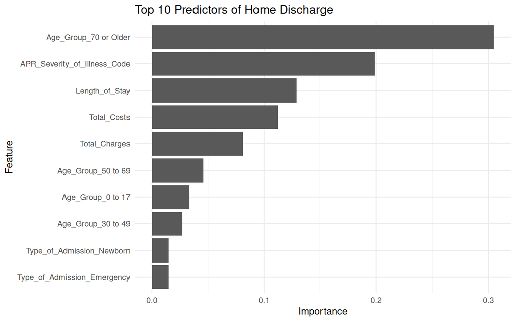

```r
rf_importance %>%
  collect() %>%
  arrange(
    desc(importance)
  ) %>%
  slice_head(
    n = 10
  ) %>%
  ggplot(
    aes(
      x =
        reorder(
          feature,
          importance
        ),
      y =
        importance
    )
  ) +
  geom_col() +
  coord_flip() +
  labs(
    title =
      "Top 10 Predictors of Home Discharge",
    x =
      "Feature",
    y =
      "Importance"
  ) +
  theme_minimal()
```

# 5. Visualizations and Final Results

# Correlation Heatmap

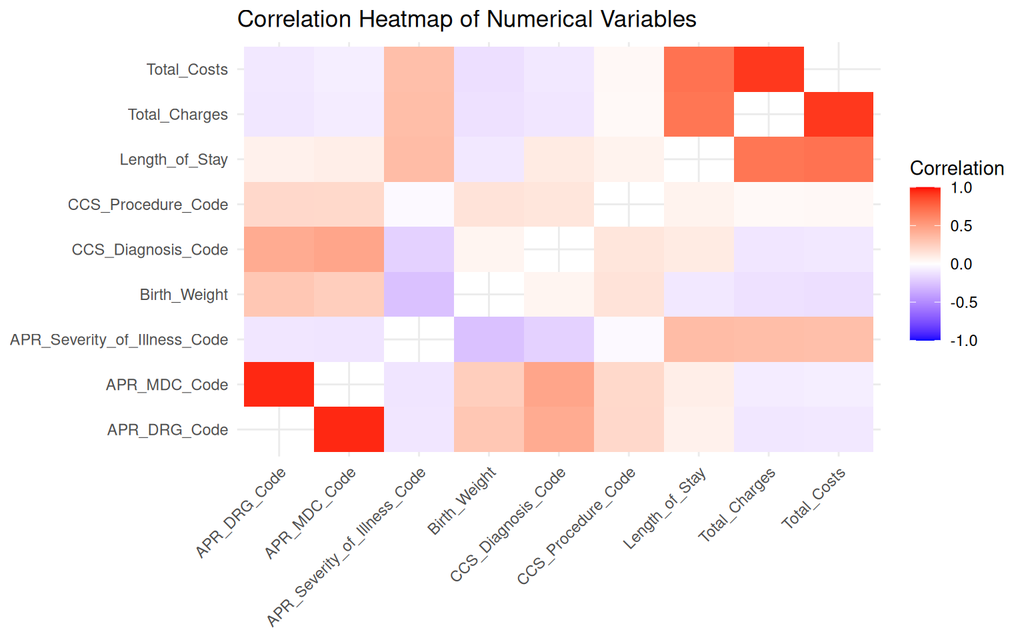

```r
numeric_df <- sparcs_clean %>%
  select(
    Length_of_Stay,
    CCS_Diagnosis_Code,
    CCS_Procedure_Code,
    APR_DRG_Code,
    APR_MDC_Code,
    APR_Severity_of_Illness_Code,
    Birth_Weight,
    Total_Charges,
    Total_Costs
  ) %>%
  collect()


cor_matrix <- numeric_df %>%
  correlate(
    use = "pairwise.complete.obs",
    method = "pearson"
  )


heatmap_data <- cor_matrix %>%
  stretch()


heatmap_data %>%
  filter(
    !is.na(r)
  ) %>%
  ggplot(
    aes(
      x = x,
      y = y,
      fill = r
    )
  ) +
  geom_tile() +
  scale_fill_gradient2(
    low = "blue",
    mid = "white",
    high = "red",
    midpoint = 0,
    limits = c(-1,1)
  ) +
  theme_minimal() +
  theme(
    axis.text.x =
      element_text(
        angle = 45,
        hjust = 1
      )
  ) +
  labs(
    title =
      "Correlation Heatmap of Numerical Variables",
    x = NULL,
    y = NULL,
    fill = "Correlation"
  )
```

# Length of Stay Distribution

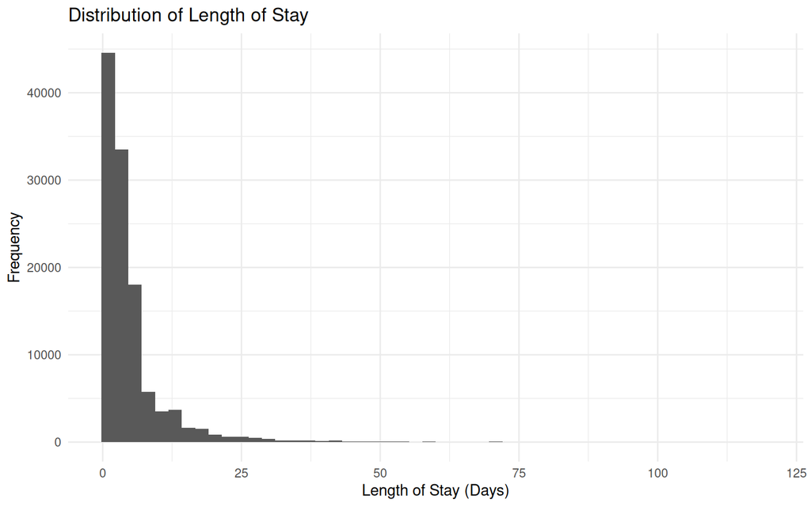

```r
sparcs_clean %>%
  select(
    Length_of_Stay
  ) %>%
  sdf_sample(
    fraction = 0.05
  ) %>%
  collect() %>%
  ggplot(
    aes(
      x = Length_of_Stay
    )
  ) +
  geom_histogram(
    bins = 50
  ) +
  labs(
    title =
      "Distribution of Length of Stay",
    x =
      "Length of Stay (Days)",
    y =
      "Frequency"
  ) +
  theme_minimal()
```

# Total Costs Distribution

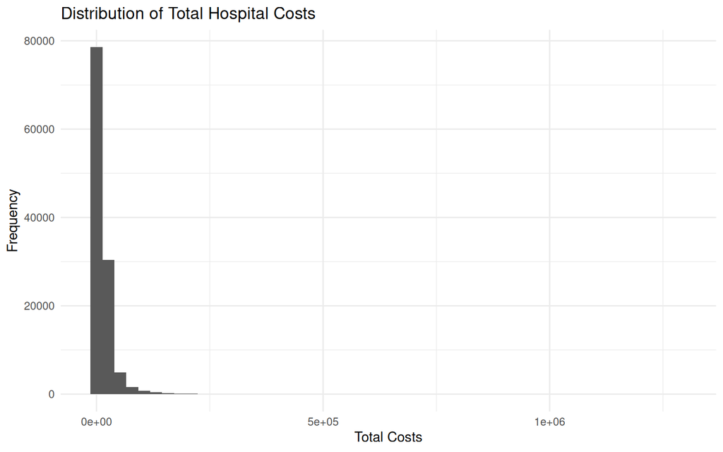

```r
sparcs_clean %>%
  select(
    Total_Costs
  ) %>%
  sdf_sample(
    fraction = 0.05
  ) %>%
  collect() %>%
  ggplot(
    aes(
      x = Total_Costs
    )
  ) +
  geom_histogram(
    bins = 50
  ) +
  labs(
    title =
      "Distribution of Total Hospital Costs",
    x =
      "Total Costs",
    y =
      "Frequency"
  ) +
  theme_minimal()
```